# FML_Assignment2

Pavan Kumar Mekala

2024-02-25

## 1A: The new_customer1 will be classified as 0 and have not taken the personal loan

[output not shown]

Prediction 0 1 0 1776 51 1 22 151 True positive = 151 True negative = 1776 False positive = 22 False negative = 51

## 5A:

Training data: Accuracy = 97.36% Sensitivity = 74.90% Specificity = 99.87%

Validation data: Accuracy = 95.8% Sensitivity = 67.15% Specificity = 98.67%

For Testing data: Accuracy = 95.8% Sensitivity = 67.39% Specificity = 98.68%

## The library functions class and caret was loaded by using library() function

```r
library(class)
library(caret)
library(e1071)
```

##Importing the dataset UniversalBank(1).csv file into Rstudio

```r
UniversalBank <- read.csv("UniversalBank (1).csv")
head(UniversalBank)
```

```
##   ID Age Experience Income ZIP.Code Family CCAvg Education Mortgage
## 1  1  25          1     49    91107      4   1.6         1        0
## 2  2  45         19     34    90089      3   1.5         1        0
## 3  3  39         15     11    94720      1   1.0         1        0
## 4  4  35          9    100    94112      1   2.7         2        0
## 5  5  35          8     45    91330      4   1.0         2        0
## 6  6  37         13     29    92121      4   0.4         2      155
##   Personal.Loan Securities.Account CD.Account Online CreditCard
## 1             0                  1          0      0          0
## 2             0                  1          0      0          0
## 3             0                  0          0      0          0
## 4             0                  0          0      0          0
## 5             0                  0          0      0          1
## 6             0                  0          0      1          0
```

```r
dim(UniversalBank)
```

```
## [1] 5000   14
```

##Transposing the dataframe of UniversalBank by using function “t”

```r
t(t(names(UniversalBank)))
```

```
##       [,1]
##  [1,] "ID"
##  [2,] "Age"
##  [3,] "Experience"
##  [4,] "Income"
##  [5,] "ZIP.Code"
##  [6,] "Family"
##  [7,] "CCAvg"
##  [8,] "Education"
##  [9,] "Mortgage"
## [10,] "Personal.Loan"
## [11,] "Securities.Account"
## [12,] "CD.Account"
## [13,] "Online"
## [14,] "CreditCard"
```

## Removing ID nad ZIP

```r
UniversalBank <- UniversalBank[,-c(1,5)]
head(UniversalBank)
```

```
##   Age Experience Income Family CCAvg Education Mortgage Personal.Loan
## 1  25          1     49      4   1.6         1        0             0
## 2  45         19     34      3   1.5         1        0             0
## 3  39         15     11      1   1.0         1        0             0
## 4  35          9    100      1   2.7         2        0             0
## 5  35          8     45      4   1.0         2        0             0
## 6  37         13     29      4   0.4         2      155             0
##   Securities.Account CD.Account Online CreditCard
## 1                  1          0      0          0
## 2                  1          0      0          0
## 3                  0          0      0          0
## 4                  0          0      0          0
## 5                  0          0      0          1
## 6                  0          0      1          0
```

```r
dim(UniversalBank)
```

```
## [1] 5000   12
```

## Coverting Education as factor

```r
UniversalBank$Education <- as.factor(UniversalBank$Education)
```

## Converting Education levels to dummy variables and creating dummy variables for factors

```r
Dummy_Education_levels <- dummyVars(~., data = UniversalBank)
Universal_Bank <- as.data.frame(predict(Dummy_Education_levels,UniversalBank))
```

## Partition the data into training (60%) and validation (40%) sets and adding set.seed(123) for reproducibility and checked them by using dim function

```r
set.seed(123)
Number_of_rows <- nrow(Universal_Bank)
Training_Universal_Bank_Index <- sample(row.names(Universal_Bank), 0.6 * Number_of_rows)
Training_Universal_Bank <- Universal_Bank[Training_Universal_Bank_Index,]
Validation_Universal_Bank_Index <- setdiff(row.names(Universal_Bank), Training_Universal_Bank_Index)
Validation_Universal_Bank <- Universal_Bank[Validation_Universal_Bank_Index,]
dim(Training_Universal_Bank)
```

```
## [1] 3000   14
```

```r
dim(Validation_Universal_Bank)
```

```
## [1] 2000   14
```

## PreProcessing the data by using preProcess() function and Normalizing the Training and Validation data predict() function

```r
Trainining_Norm_Universal_Bank <- Training_Universal_Bank [,-10]
Validation_Norm_Universal_Bank <- Validation_Universal_Bank [,-10]
Normalization_Values <- preProcess(Training_Universal_Bank[,-10], method=c("center","scale"))
Trainining_Norm_Universal_Bank <- predict(Normalization_Values, Training_Universal_Bank[,-10])
Validation_Norm_Universal_Bank <- predict(Normalization_Values, Validation_Universal_Bank[,-10])
```

## Creating the dataset and normalizing it by using predict() function

```r
New_customer1 <- data.frame(
  Age = 40,
  Experience = 10,
  Income = 84,
  Family = 2,
  CCAvg = 2,
  Education.1 = 0,
  Education.2 = 1,
  Education.3 = 0,
  Mortgage = 0,
  Securities.Account = 0,
  CD.Account = 0,
  Online = 1,
  CreditCard = 1
)
New_customer1_Norm <- New_customer1
New_customer1_Norm <- predict(Normalization_Values, New_customer1_Norm)
```

## Performing knn classification as k=1 and predicting it by using class::knn() function

```r
knn_Prediction_1 <- class::knn(train = Trainining_Norm_Universal_Bank,
                               test = New_customer1_Norm,
                               cl = Training_Universal_Bank$Personal.Loan, k=1)
knn_Prediction_1
```

```
## [1] 0
## Levels: 0 1
```

## Calculating the accuracy of each value of k and checked it by using print(paste) function

```r
Accuracy_bank <- data.frame(k= seq(1, 20, 1), overallaccuracy = rep(0,20))
for (i in 1:20){
  knn_prediction <- class::knn (train = Trainining_Norm_Universal_Bank,
                                test = Validation_Norm_Universal_Bank,
                                cl = Training_Universal_Bank$Personal.Loan, k=i)

Accuracy_bank[i, 2] <- confusionMatrix(knn_prediction, as.factor(Validation_Universal_Bank$Personal.Loan),
                                                   positive = "1")$overall[1]
}
Best_Value_K <- which(Accuracy_bank[,2] == max(Accuracy_bank[,2]))
Accuracy_bank
```

```
##     k overallaccuracy
## 1   1          0.9635
## 2   2          0.9575
## 3   3          0.9585
## 4   4          0.9570
## 5   5          0.9545
## 6   6          0.9525
## 7   7          0.9545
## 8   8          0.9515
## 9   9          0.9495
## 10 10          0.9485
## 11 11          0.9465
## 12 12          0.9460
## 13 13          0.9465
## 14 14          0.9475
## 15 15          0.9435
## 16 16          0.9445
## 17 17          0.9435
## 18 18          0.9445
## 19 19          0.9420
## 20 20          0.9395
```

```r
print(paste("Best value of k =", Best_Value_K))
```

```
## [1] "Best value of k = 1"
```

## Plotting the graph between the values of k accuracy

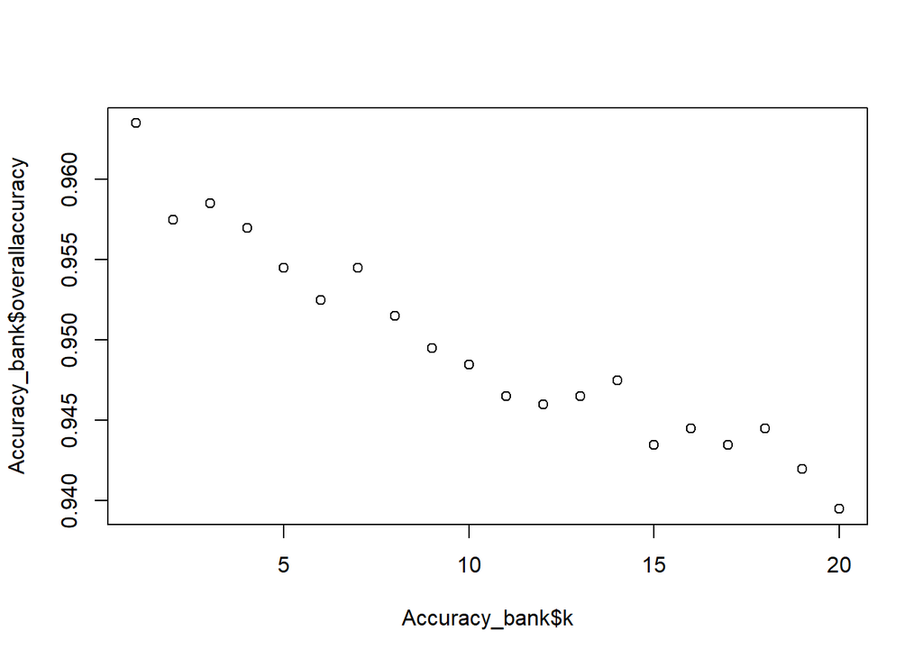

```r
plot(Accuracy_bank$k, Accuracy_bank$overallaccuracy)
```

## Creating the confusion matrix of validation data for the best value of k and checked it by using print() function

```r
knn_Predicion_2 <- class::knn(train = Trainining_Norm_Universal_Bank,
                        test = Validation_Norm_Universal_Bank,
                        cl = Training_Universal_Bank$Personal.Loan,k = Best_Value_K)
Confusion_matrix_Data <- confusionMatrix(knn_Predicion_2, as.factor(Validation_Universal_Bank$Personal.Loan), positive = "1")
print(Confusion_matrix_Data)
```

```
## Confusion Matrix and Statistics
##
##           Reference
## Prediction    0    1
##          0 1776   51
##          1   22  151
##
##                Accuracy : 0.9635
##                  95% CI : (0.9543, 0.9713)
##     No Information Rate : 0.899
##     P-Value [Acc > NIR] : < 2.2e-16
##
##                   Kappa : 0.7853
##
##  Mcnemar's Test P-Value : 0.001049
##
##             Sensitivity : 0.7475
##             Specificity : 0.9878
##          Pos Pred Value : 0.8728
##          Neg Pred Value : 0.9721
##              Prevalence : 0.1010
##          Detection Rate : 0.0755
##    Detection Prevalence : 0.0865
##       Balanced Accuracy : 0.8676
##
##        'Positive' Class : 1
##
```

## Creating new dataset and normalizing the data

```r
New_customer2 <- data.frame(
  Age = 40,
  Experience = 10,
  Income = 84,
  Family = 2,
  CCAvg = 2,
  Education.1 = 0,
  Education.2 = 1,
  Education.3 = 0,
  Mortgage = 0,
  Securities.Account = 0,
  CD.Account = 0,
  Online = 1,
  CreditCard = 1
)
New_Customer2_Norm <- New_customer2
New_Customer2_Norm <- predict(Normalization_Values, New_Customer2_Norm)
```

## Predicting the data by using knn Algorithm

```r
knn_Prediction_3 <- class::knn(train = Trainining_Norm_Universal_Bank,
                        test = New_Customer2_Norm,
                        cl = Training_Universal_Bank$Personal.Loan, k = Best_Value_K)
knn_Prediction_3
```

```
## [1] 0
## Levels: 0 1
```

## Splitting data again for training, validation and testing and setting the seed value as 134 and the dimensions by using dim() functions

```r
set.seed(134)
Training_Universal_Bank_Index2 <- sample(row.names(Universal_Bank), 0.5 * Number_of_rows)
Validation_Universal_Bank_Index_2 <- sample(setdiff(row.names(Universal_Bank),Training_Universal_Bank_Index2),
                      0.3 * Number_of_rows)
Testing_Universal_Bank_Index <- setdiff(row.names(Universal_Bank), c(Training_Universal_Bank_Index2,Validation_Universal_Bank_Index_2))

Training_Universal_Bank_2 <- Universal_Bank[Training_Universal_Bank_Index2,]
Validation_Universal_Bank2 <- Universal_Bank[Validation_Universal_Bank_Index_2,]
Testing_Universal_Bank <- Universal_Bank[Testing_Universal_Bank_Index,]
dim(Training_Universal_Bank_2)
```

```
## [1] 2500   14
```

```r
dim(Validation_Universal_Bank2)
```

```
## [1] 1500   14
```

```r
dim(Testing_Universal_Bank)
```

```
## [1] 1000   14
```

## Normalizing the data for Training, Validation and Testing by using predict() function and preprocessing it by using preProcess() function and checked it by using print() function

```r
set.seed(134)
Normalization_Values2 <- preProcess(Training_Universal_Bank_2[ ,-10], method = c("center", "scale"))
Trainining_Norm_Universal_Bank_2 <- predict(Normalization_Values2, Training_Universal_Bank_2[ ,-10])
Validation_Norm_Universal_Bank_2 <- predict(Normalization_Values2, Validation_Universal_Bank2[ ,-10])
Testing_Norm_Universal_Bank_2 <- predict(Normalization_Values2, Testing_Universal_Bank[ ,-10])
```

## Confusion matrix for training data at k=3

```r
knn_Prediction_Training <- class::knn(train = Trainining_Norm_Universal_Bank_2,
                             test = Trainining_Norm_Universal_Bank_2,
                             cl = Training_Universal_Bank_2$Personal.Loan, k = 3)
Confusion_matrix_Train <- confusionMatrix(knn_Prediction_Training, as.factor(Training_Universal_Bank_2$Personal.Loan), positive = "1")
print(Confusion_matrix_Train)
```

```
## Confusion Matrix and Statistics
##
##           Reference
## Prediction    0    1
##          0 2246   63
##          1    3  188
##
##                Accuracy : 0.9736
##                  95% CI : (0.9665, 0.9795)
##     No Information Rate : 0.8996
##     P-Value [Acc > NIR] : < 2.2e-16
##
##                   Kappa : 0.8365
##
##  Mcnemar's Test P-Value : 3.803e-13
##
##             Sensitivity : 0.7490
##             Specificity : 0.9987
##          Pos Pred Value : 0.9843
##          Neg Pred Value : 0.9727
##              Prevalence : 0.1004
##          Detection Rate : 0.0752
##    Detection Prevalence : 0.0764
##       Balanced Accuracy : 0.8738
##
##        'Positive' Class : 1
##
```

```r
knn_Prediction_Validation_2 <- class::knn(train =Trainining_Norm_Universal_Bank_2,
                                        test = Validation_Norm_Universal_Bank_2,
                                        cl = Training_Universal_Bank_2$Personal.Loan, k = Best_Value_K)
Confusion_matrix_Validation_2 <- confusionMatrix(knn_Prediction_Validation_2, as.factor(Validation_Universal_Bank2$Personal.Loan), positive = "1")
print(Confusion_matrix_Validation_2)
```

```
## Confusion Matrix and Statistics
##
##           Reference
## Prediction    0    1
##          0 1345   45
##          1   18   92
##
##                Accuracy : 0.958
##                  95% CI : (0.9466, 0.9676)
##     No Information Rate : 0.9087
##     P-Value [Acc > NIR] : 1.639e-13
##
##                   Kappa : 0.7224
##
##  Mcnemar's Test P-Value : 0.001054
##
##             Sensitivity : 0.67153
##             Specificity : 0.98679
##          Pos Pred Value : 0.83636
##          Neg Pred Value : 0.96763
##              Prevalence : 0.09133
##          Detection Rate : 0.06133
##    Detection Prevalence : 0.07333
##       Balanced Accuracy : 0.82916
##
##        'Positive' Class : 1
##
```

```r
knn_Prediction_Testing <- class::knn(train = Trainining_Norm_Universal_Bank_2,
                                     test = Testing_Norm_Universal_Bank_2,
                                     cl = Training_Universal_Bank_2$Personal.Loan, k = Best_Value_K)
Confusion_matrix_testing <- confusionMatrix(knn_Prediction_Testing, as.factor(Testing_Universal_Bank$Personal.Loan), positive = "1")
print(Confusion_matrix_testing)
```

```
## Confusion Matrix and Statistics
##
##           Reference
## Prediction   0   1
##          0 896  30
##          1  12  62
##
##                Accuracy : 0.958
##                  95% CI : (0.9436, 0.9696)
##     No Information Rate : 0.908
##     P-Value [Acc > NIR] : 1.093e-09
##
##                   Kappa : 0.7244
##
##  Mcnemar's Test P-Value : 0.008712
##
##             Sensitivity : 0.6739
##             Specificity : 0.9868
##          Pos Pred Value : 0.8378
##          Neg Pred Value : 0.9676
##              Prevalence : 0.0920
##          Detection Rate : 0.0620
##    Detection Prevalence : 0.0740
##       Balanced Accuracy : 0.8303
##
##        'Positive' Class : 1
##
```